# Practice Project Data Analysis Report for Math Score

(Xiuxiao Hughes, ID:997786440)

# 1 Abstract

In order to increase the high school graduation rate, a study was conducted to see if the math score was different by 3 class types and 76 schools’ ID. The data used in this study was a subset of the dataset called STAR. An initial visualizations of the dataset showed that math score may have effects by class types and schools ID. I then fitted a two-way ANOVA model.It’s assumption of normality, independence and equal variance were all met. The outcome of this model showed students who were enrolled in a small class had the highest mean math score. However, the math score by schools’ IDs was not easy to interpret because their were too many different schools. This is the part we need to improve in the future. Overall, this is a successful data analysis study.

# 2 Introduction

According to the report from the U.S. News, the high school graduation rate for year 2018-2019 is 88% which reached the average rate compared to the previous years. However, the high school graduation rate from some states is much lower than the U.S. average rate. For example, Arizona has 75% high school graduation rate, and New Mexico and Washington DC have 76%. Having a higher high school graduation rate is important not only for personal, but also for society. Anyone who holds a high school diploma is easy to find jobs with higher paid. Also, they have the ability to build stronger work habits and skills for their careers. In addition, a state where has a higher high school graduation rate grows the local economies better. So, the purpose of this study is to find a way to help students to do better in school, so that they will be able to graduate from high school. The question of interest in this project is if there are any differences in math scaled scores in the first grade across class sizes. If so, which class size is associated with the highest math scaled scores in the first grade.

# 3 Background

The dataset STAR from The Tennessee’s Student / Teacher Achievement Ratio study was first collected in last 1980’s in Tennessee State. The dataset was found from [Harvard dataverse](https://dataverse.harvard.edu/dataset.xhtml?persistentId=hdl:1902.1/10766).The aim for this data set was to determine if the class sizes affect student’s exam scores for students from kindergarten through third grade. There are three different class sizes which are small class (13-17 students), regular class (22-26 students) and regular class (22-26 students) with a teacher aide. All students enrolled in classes were randomly assigned to a different size of classes. This dataset contains 11601 observations and 379 variables. For this project, we are only examining students’ math scaled scores at their first grade in three different class sizes. Also, we treated each class as an observation, so each element in the math scaled score variable is the mean score of each class. We also studied the math scaled scores by school ID, so we only used four variables from the STAR dataset. The variable “school” represents school ID, “id” represents teacher ID, “class” represents class types (1-small class, 2-regular class, 3-regular class with a teacher aide), and “mathss” represents math scaled scores. The variables “school”, “id” and “class” are factors, and the variable “mathss” is numeric.

# 4 Descriptive analysis

```
##      school            id        class          mathss
##  169229 : 238   16821107:  30   1   :1925   Min.   :404.0
##  201449 : 149   16821110:  30   2   :2584   1st Qu.:500.0
##  244806 : 142   16821108:  29   3   :2320   Median :529.0
##  257905 : 134   20549205:  29   NA's:4772   Mean   :530.5
##  244708 : 127   20549206:  29               3rd Qu.:557.0
##  (Other):6039   (Other) :6682               Max.   :676.0
##  NA's   :4772   NA's    :4772               NA's   :5003
```

From the summary table above, there are 4772 missing values from “school”, “id” and “class” variables, and 5003 missing values from “mathss”. These missing values were removed.

As it mentioned above, we treated each class as an observation, so the dataset needed to be aggregated. I used the functions group_by() and summarise() to group the math scaled scores so each element in the colmun “mathss” was the mean math scaled score of each class.

**Visualizations of the dataset:**

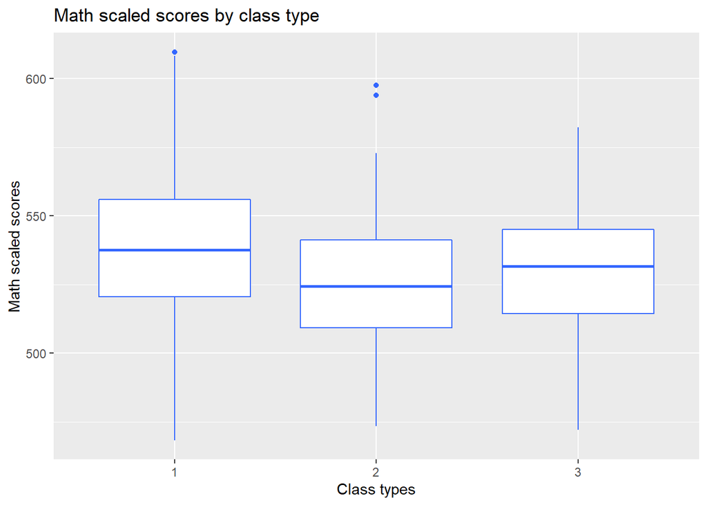

From the box plot of “Math scaled scores by class type”, we can see there may be some effects between class types because class 1 seems has higher math score.

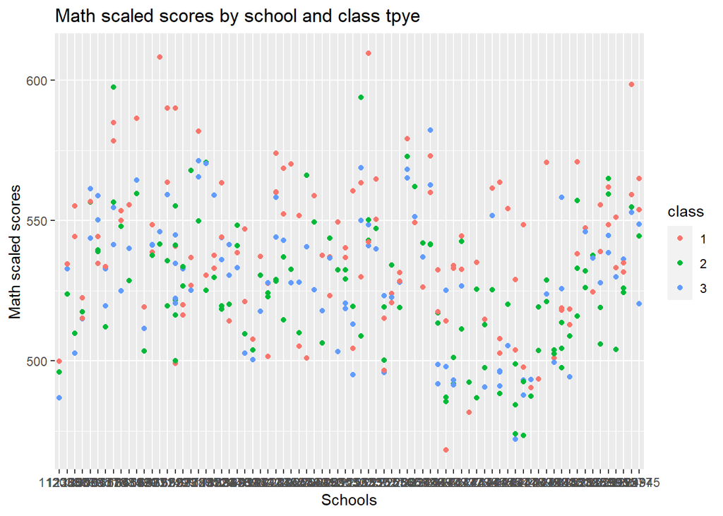

From the plot of “Math scaled scores by school and class type”, we can also see that many red dots (small class) are on top of the green and blue dots by each school, so there may be effects that students in small classes had higher math scores.

# 5 Inferential analysis

A two-way ANOVA model is suitable for this study because we need to estimate how math scaled scores changes according to the levels of two categorical variables, school and class types.

We had tried to fit two two-way ANOVA models, one(model1) was without interaction, and the other one (model2) was with interaction.

For model1, the model is$Y_{ijk} = \mu_{..} + \alpha_{i} + \beta_{j} + \epsilon_{ijk}$. The $Y_{ijk}$ is the response variable math scaled score. The $\mu_{..}$ is the population mean, $\alpha_i$ is class type, where the index $i$ represents the class type: small ($i=1$), regular ($i=2$), regular with aide ($i=3$), and $\beta_j$ is schools where the index $j=1,2...76$ represents the school indicator, and $\{\epsilon_{ijk}\}$ are i.i.d. $N(0,\sigma^2)$.

For model2, the model is $Y_{ijk} = \mu_{..} + \alpha_{i} + \beta_{j} + (\alpha\beta)_{ij} + \epsilon_{ijk}$. The $Y_{ijk}$ is the response variable math scaled score. The $\mu_{..}$ is the population mean, $\alpha_i$ is class type, where the index $i$ represents the class type: small ($i=1$), regular ($i=2$), regular with aide ($i=3$), and $\beta_j$ is schools where the index $j=1,2...76$ represents the school indicator, the $(\alpha\beta)_{ij}$ is the interaction of class types and schools, and $\{\epsilon_{ijk}\}$ are i.i.d. $N(0,\sigma^2)$.

**The assumptions of a two-way ANOVA model:**

-The populations from which the samples are obtained must be normally distributed.

-Observations for within and between groups must be independent.

-The variances among populations must be equal.

-Missing values and outliers.

**Fitting model without interaction:**

F-test for $\alpha_i$: the null and alternative hypotheses.
$$H_0: \alpha_{i}=0 \ \ \forall i \ \ \ {\rm v.s.}\ \ \ H_1:\ {\rm not \ all \ } \alpha_i \ {\rm are \ zero}.$$

According to the information of the ANOVA table below, we reject the null hypotheses because the p-value of the F-test for class type is almost equal to zero at the level of 0.05, and we concluded that the math scaled scores from different class types are not all the same.

F-test for $\beta_{j}$: the null and alternative hypotheses.
$$H_0: \beta_{j}=0 \ \ \forall j \ \ \ {\rm v.s.}\ \ \ H_1:\ {\rm not \ all \ } \beta_j \ {\rm are \ zero}.$$

According to the information of the ANOVA table below, we reject the null hypotheses because the p-value of the F-test for schools is almost equal to zero at the level of 0.05, and we concluded that the math scaled scores from different schools are not all the same.

|  | Df | Sum Sq | Mean Sq | F value | Pr(>F) |
| --- | --- | --- | --- | --- | --- |
| class | 2 | 11617.28 | 5808.6408 | 20.990866 | 3.521601e-09 |
| school | 75 | 136832.53 | 1824.4337 | 6.593013 | 1.170721e-30 |
| Residuals | 261 | 72224.52 | 276.7223 | NA | NA |

**Fitting model with interaction:**

F-test for the interaction term $(\alpha\beta)_{ij}$: the null and alternative hypotheses.
$$H_0: (\alpha\beta)_{ij}=0 \ \forall i, j \ \ {\rm v.s.} \ \ \ H_1:\ {\rm not \ all \ } (\alpha\beta)_{ij} \ {\rm are \ zero}.$$

According to the information of the ANOVA table below, we accept the null hypotheses because the p-value of the F-test for the interaction term is $0.7056$ at the level of 0.05, and we concluded that the math scaled scores have no effect from the interaction between class types and school ID.

F-test for $\alpha_{i}$: the null and alternative hypotheses.
$$H_0: \alpha_{i}=0 \ \ \forall i \ \ \ {\rm v.s.}\ \ \ H_1:\ {\rm not \ all \ } \alpha_i \ {\rm are \ zero}.$$

According to the information of the ANOVA table below, we reject the null hypotheses because the p-value of the F-test for class type is almost equal to zero at the level of 0.05, and we concluded that the math scaled scores from different class types are not all the same.

F-test for $\beta_{j}$: the null and alternative hypotheses.
$$H_0: \beta_{j}=0 \ \ \forall j \ \ \ {\rm v.s.}\ \ \ H_1:\ {\rm not \ all \ } \beta_j \ {\rm are \ zero}.$$

According to the information of the ANOVA table below, we reject the null hypotheses because the p-value of the F-test for schools is almost equal to zero at the level of 0.05, and we concluded that the math scaled scores from different schools are not all the same.

|  | Df | Sum Sq | Mean Sq | F value | Pr(>F) |
| --- | --- | --- | --- | --- | --- |
| class | 2 | 11617.28 | 5808.6408 | 19.9361813 | 3.686593e-08 |
| school | 75 | 136832.53 | 1824.4337 | 6.2617474 | 1.543266e-18 |
| class:school | 146 | 38717.92 | 265.1912 | 0.9101785 | 7.056145e-01 |
| Residuals | 115 | 33506.60 | 291.3618 | NA | NA |

We decided to use model1, the model without interaction, as the final model.

**The Tukey-Kramer testing:**

For variable “class”, the Tukey-Kramer testing is suitable because the sample size for each group is not equal. Class 1 has 124 samples, class 2 has 115 samples, and class 3 has 100 samples. The the null and alternative hypotheses.
$$H_0: \mu_{1}=\mu_{2} \\\ H_1:\ \mu_{1} \not= \mu_{2}$$
$$H_0: \mu_{1}=\mu_{3} \\\ H_1:\ \mu_{1} \not= \mu_{3}$$
$$H_0: \mu_{2}=\mu_{3} \\\ H_1:\ \mu_{2} \not= \mu_{3}$$

Based on the results from the Tukey-Kramer testing, at the level of 0.05, comparing the mean math scaled scores between class1 and class2, we rejected the null hypotheses, and concluded that the mean math scaled scores are different from class1 and class2.

Based on the results from the Tukey-Kramer testing, at the level of 0.05, comparing the mean math scaled scores between class1 and class3, we rejected the null hypotheses, and concluded that the mean math scaled scores are different from class1 and class3.

Based on the results from the Tukey-Kramer testing, at the level of 0.05, comparing the mean math scaled scores between class2 and class3, we accepted the null hypotheses, and concluded that the mean math scaled scores are the same from class2 and class3.

```
##           diff        lwr       upr        p adj
## 2-1 -13.580024 -18.656367 -8.503681 3.651884e-09
## 3-1  -9.485401 -14.755575 -4.215226 9.091937e-05
## 3-2   4.094623  -1.266825  9.456071 1.715156e-01
```

The class1(small class) has the highest mean math scaled score which is $538.9852$.

```
##        1        2        3
## 538.9852 525.4052 529.4998
```

```
##                   diff        lwr      upr        p adj
## 130085-112038 60.79492  6.9265282 114.6633 6.105981e-03
## 159171-112038 50.14150  0.2690564 100.0139 4.616378e-02
## 161183-112038 74.65346 24.7810183 124.5259 2.668954e-06
## 165199-112038 75.88901 18.3012743 133.4767 1.493615e-04
## 168214-112038 71.05812 13.4703878 128.6459 8.366314e-04
## 169219-112038 59.02459  7.5165502 110.5326 4.467157e-03
```

# 6 Sensitivity analysis

**As mentioned above, the assumptions of a two-way ANOVA model are as followed:**

-The populations from which the samples are obtained must be normally distributed.

-Observations for within and between groups must be independent.

-The variances among populations must be equal.

-Missing values and outliers.

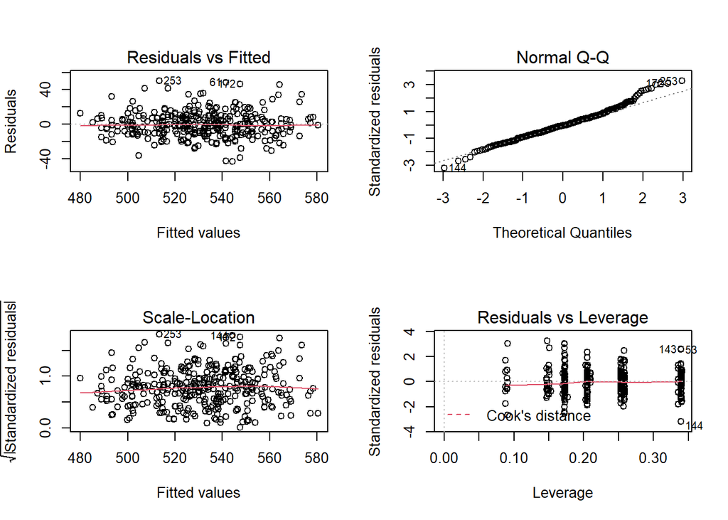

The residual vs. fitted value plot does not show any pattern indicating that a linear relationship is appropriate. The expected value of the residuals is approximately 0 indicating that variance is approximately constant. The Q-Q plot is almost a straight line, so their normality assumption is met. There is no obvious outlier in the dataset. The missing values had been removed, so there is no missing values.

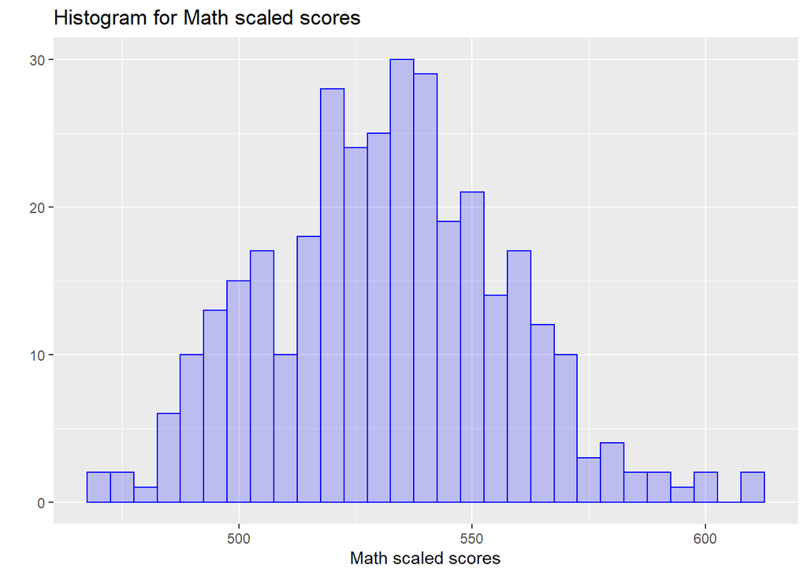

From the plot of “Histogram for Math scaled scores”, the response variable “mathss” is normally distributed.

As mentioned in the introduction section, students enrolled in classes were randomly assigned to different class types, so the Observations for within and between groups should be independent.

A Levene’s test was conducted to see if the equal variance assumption met. The p-value of the F-test for variable math scores and classs are $0.5452$ which is large, so at the level of $\ 0.05$, we accepted the null hypothesis $H_0: \mathbb{E}[d_{1\cdot}]=\mathbb{E}[d_{2\cdot}] = \mathbb{E}[d_{3\cdot}]$ where $d_{ij}=|Y_{ij}-\bar{Y}_{i\cdot}|$. And we conclude that the variances are equal.

The p-value of the F-test for variable math scores and schools are $0.7458$ which is large, so at the level of $\ 0.05$, we accepted the null hypothesis $H_0: \mathbb{E}[d_{1\cdot}]=\mathbb{E}[d_{2\cdot}] = \ {...}= \mathbb{E}[d_{j\cdot}]$ where$j=1,2,...,76$ and $d_{ij}=|Y_{ij}-\bar{Y}_{i\cdot}|$. And we conclude that the variances are equal.

|  | Df | F value | Pr(>F) |
| --- | --- | --- | --- |
| group | 2 | 0.6076908 | 0.5452045 |
|  | 336 | NA | NA |

|  | Df | F value | Pr(>F) |
| --- | --- | --- | --- |
| group | 75 | 0.8775795 | 0.7457615 |
|  | 263 | NA | NA |

# 7 Discussion

After studying the math scaled scores for students in the 1st grade from the dataset STAR, we found out that the math score was significant different between class types at the level of 0.05. The smallest class size with 13-17 students had the highest mean math score. And it didn’t matter if a regular size class with a teacher aide or without a teacher aide because their math score had not different.

There are four variables in the STAR dataset were used. The variable, teacher ID, was used to calculated the mean math score for each class.So there three variables after we combined them all together. The response variable is a numeric variable, the two other variables are factors, so, the two-way ANOVA model was suitable for the study. Also, the sample size were not equal, so the Tukey-Kramer test is suitable to use as the post-Hoc test. Moreover, the assumptions of normality, independence and equal variance were all met. So, the conclusion for this analysis in general is good.

# Acknowledgement

I have discussed this project with one of my teammates.

# Reference

Perry, M. (2021, January 23). What are the benefits of having a high school diploma? wiseGEEK: clear answers for common questions. Retrieved January 20, 2022, from https://www.wise-geek.com/what-are-the-benefits-of-having-a-high-school-diploma.htm#:~:text=A%20diploma%20doesn’t%20just,t%20graduate%20from%20high%20school

Emma, Kerr. (2021, April 28). See high school graduation rates by State. U.S. News & World Report. Retrieved January 20, 2022, from https://www.usnews.com/education/best-high-schools/articles/see-high-school-graduation-rates-by-state#:~:text=The%20high%20school%20graduation%20rate,News%20Best%20High%20Schools%20rankings.

C.M. Achilles; Helen Pate Bain; Fred Bellott; Jayne Boyd-Zaharias; Jeremy Finn; John Folger; John Johnston; Elizabeth Word, 2008, “Tennessee’s Student Teacher Achievement Ratio (STAR) project”, https://doi.org/10.7910/DVN/SIWH9F, Harvard Dataverse, V1, UNF:3:Ji2Q+9HCCZAbw3csOdMNdA== [fileUNF]

# Appendix Code

```r
library("haven")
library(dplyr)
library(ggplot2)
library(car)
STAR <- read_sav("C:/Users/xiuxi/Downloads/dataverse_files/STAR_Students.sav")
star<-data.frame(STAR$g1schid,STAR$g1tchid,STAR$g1classtype, STAR$g1tmathss)
names(star)[names(star) == "STAR.g1tchid"] <- "id"
names(star)[names(star) == "STAR.g1classtype"] <- "class"
names(star)[names(star) == "STAR.g1tmathss"] <- "mathss"
names(star)[names(star) == "STAR.g1schid"] <- "school"
star$class<-as.factor(star$class)
star$id<-as.factor(star$id)
star$school<-as.factor(star$school)
summary(star)
##removing missing values
mv<-colSums(is.na(star))
star.rn<-na.omit(star)
data<-star.rn %>%
  group_by(school, id, class) %>%
  summarize(math = mean(mathss),.groups = "keep")
p <- ggplot(data, aes(class, math))
p + geom_boxplot(fill = "white", colour = "#3366FF")+
  ggtitle("Math scaled scores by class type")+
  xlab("Class types") + ylab("Math scaled scores")
ggplot(data, aes(x=school, y=math, colour=class)) +
  geom_point()+
  ggtitle("Math scaled scores by school and class tpye") +
   xlab("Schools") + ylab("Math scaled scores")
model1<-lm(math~class+school, data=data)
anova(model1)
model2<-lm(math~class+school+class*school, data=data)
anova(model2)
#Tukey-Kramer method
tkm<-TukeyHSD(aov(model1), conf.level=.95)
tkm$class
tapply(data$math,data$class,mean)
tkm.sc<-tkm$school
tkm.sc1<-as.matrix(tkm.sc)
a<-length(tkm.sc1[tkm.sc1[,4]<0.05,4])# there are 263 pairs of schools that have a different math scores
b<-length(tkm.sc1)#there are total 11400 pairs of schools in the tests.
head(tkm.sc1[tkm.sc1[,4]<0.05,c(1:4)])
par(mfrow = c(2, 2))
plot(model1)
qplot(data$math,
      geom="histogram",
      binwidth = 5,
      main = "Histogram for Math scaled scores",
      xlab = "Math scaled scores",
      fill=I("blue"),
      col=I("blue"),
      alpha=I(.2))
# Levene test:
leveneTest(math ~ class, data = data)
leveneTest(math ~ school, data = data)
```